# EE550 HW-5

Erhan Can Ozcan

5/15/2019

## Continuous Hopfield Model

In this homework, we are asked to simulate continuous type Hopfield Neural Network with 2 neurons. T matrix is a (2 by 2) square matrix and can be formulated as 1-(identity matrix). Additionally, C and R are given as 1. Lambda is set to 1.4, initially. In each neuron, following function is used as an activation function: g(u) = $2\over{\pi}$ * arctan(${\pi\lambda}u\over2$)

The overall model can be described with the following equations:

${C_i}\frac{du_i}{dt}+\frac{u_i}{R_i}=\sum\limits_{j=1}^{2}{T_{ij}*V_j}+I_i$ for i=1,2

$v_i=g(u_i)$ for i=1,2

In equilibrium points, we know that $\frac{du_1}{dt}=\frac{du_2}{dt}=0$. Under the light of this fact, we can calculate the equlibrium points through solving the following two differential equations **(Eq1)**:

$\frac{du_1}{dt}=-u_1+g(u_2)$

$\frac{du_2}{dt}=-u_2+g(u_1)$

To be able to solve these two equations, I have used a numeric solver called as uniroot in R. It searches a specific interval to find a root for target function.

To calculate the energy for all $v_1$ and $v_2$ pairs in the region;

$-1\leq{v_1}\leq{1}$

$-1\leq{v_2}\leq{1}$

(Note that we need to discretize the region to obtain $v_1,v_2$ pairs. Therefore, I have obtained pairs by decreasing 0.01 either $v_1$ or $v_2$)

The following equation **(Eq2)** is utilized.

$E=\frac{1}{2}\sum\limits_i\sum\limits_jT_{ij}v_iv_j + \frac{1}{\lambda} \sum\limits_i \frac{1}{R_i} \int\limits_{0}^{v_i}g^{-1}(\epsilon)d_{\epsilon}$

To be able to calculate the integral, I have utilized Riemann sum approach.

## Question 1

The precision in desired six energy levels is three. Thus, calculated energy values are rounded. Finally, only the pairs that produce the given 6 energy levels are determined, and the contour plot below is plotted with the 3 equilibrium points (0,0) , (-0.573,-0.573) , (0.573,0.573)

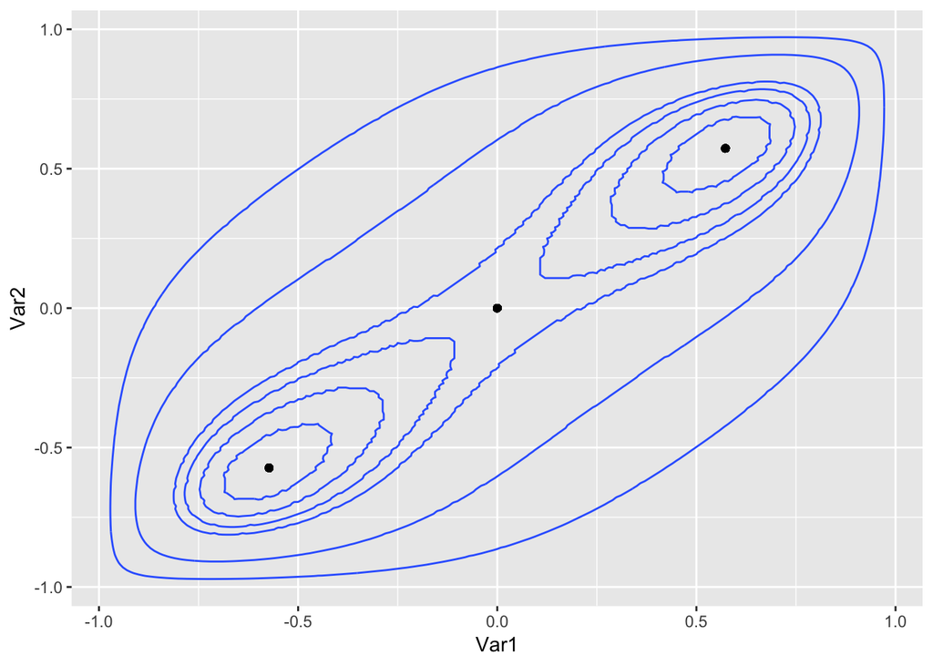

From outside to inside energy levels are “0.449,0.156,0.017,-0.003,-0.023,-0.041” and three dot on the plots represent the equilibrium points for $\lambda$=1.4.

## Question 2

In this Question by adding random normal noise (with mean=0 and sd=0.2) to one of the equailibrium points, a new point is obtained. The green point represents this new point. Then, using the differential equations in **(Eq1)** location of point is updated. While updating the location, step size is taken as 0.01 to avoid big steps and cycling. To show the convergence of model to the equilibrium point, at some steps, current location of the point is shown with red points. The point is updated until both $v_1$ and $v_2$ is closer to the equilibrium point less than 0.001. Finally, when it stops, the state of the system is shown with a cyan point. (Note that in reference 1, it is stated that two equlibrium points except(0,0) are stable. I selected the equlibrium point in the third quadrant, and I disturbed it via random noise, and simulated the convergence. Same analysis can be also conducted for the equilibrium point in the first quadrant.)

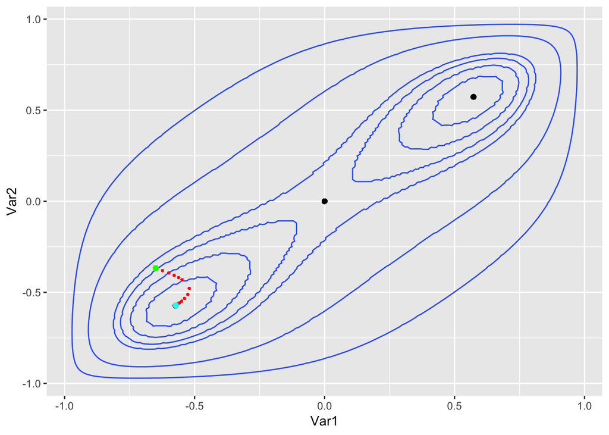

## Question 3

We know that increasing the value of $\lambda$ forces system to behave like discrete time Hopfield Model. Therefore, we expect equlibrium points to shift toward corners. To observe this behaviour, $\lambda$ is increased by 0.1 and equlibrium points are re-calculated through equating the equations in **(Eq1)** to **0**

When equilibrium points are adjacent to the corner points, lambda is equal to 90.5

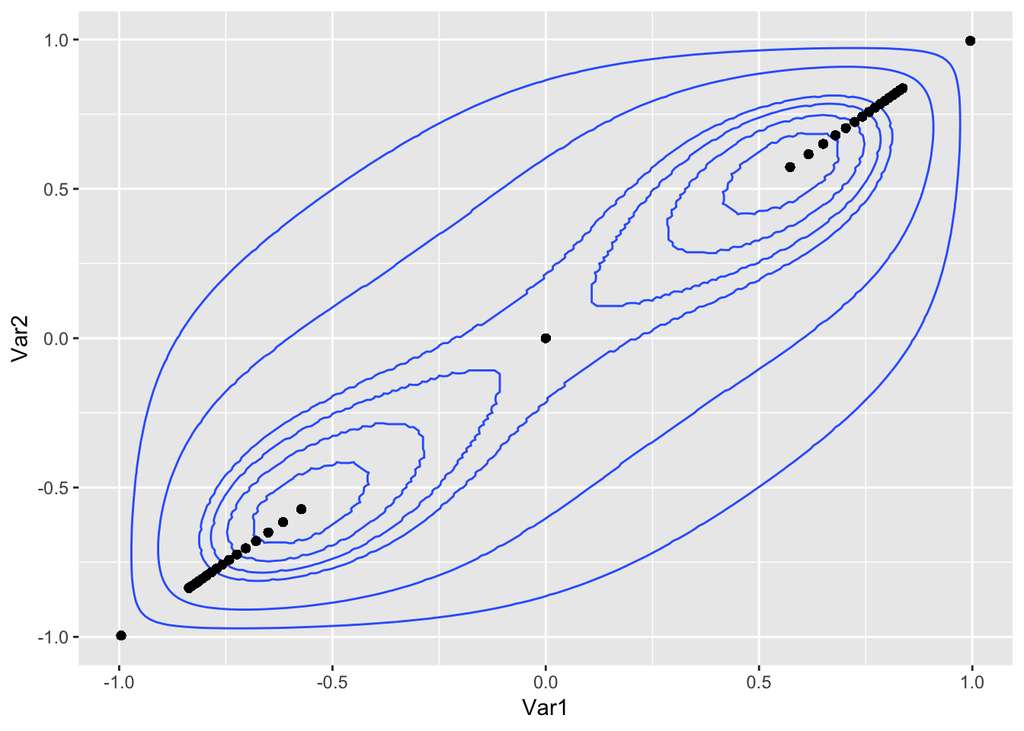

# REFERENCES

[1 ]M.K.CilizandA.Harova,“StabilityRegionsofRecurrentType Neural Networks”, Electronics Letters, Vol. 28, No 11, pp.1022- 1024, May 1992.

[2 ] J. J. Hopfield, “Neurons with graded response have collective computational properties like those of two state neurons” Porc. Nat. Acd. Sci., Vol. 81,pp.3088-3092, May 1984.

# CODE

```r
library(data.table)
library(ggplot2)
#arctan(1) in terms of radian
atan(1)
#see pi/4 equals to atan(1)
pi/4

#arctan(1) in terms of degree
atan(1)*57.29578
lambda=1.4
#note that C_i and R_i i ranges from 1 to N. i : no_of_neurons. In our case
#values are equal to 1. C_1=C_2=1 && R_1=R_2=1
#also T_ij matrix is given as
##0 1
##1 0 Therefore, to simplify the calculations, I will not use this matrix
#in the code
C_i=1
R_i=1
I_i=0
atan(lambda*pi*1/2)*(2/pi)


#find eq points

g_u<-function(u,lambda){
  return((2/pi)*atan((lambda*pi*u)/2))
}

find_equil<-function(u2,lambda){
  u1_tmp=g_u(u2,lambda = lambda)
  u2_tmp=g_u(u1_tmp,lambda = lambda)
  return(u2-u2_tmp)
}
negative_u2=uniroot(find_equil,lower = -1,upper = -0.01,tol = 10^-15,lambda=lambda)$root
negative_u1=g_u(negative_u2,lambda)
positive_u2=uniroot(find_equil,lower = 0.001,upper = 1,tol = 10^-15,lambda=lambda)$root
positive_u1=g_u(positive_u2,lambda)
naive_u2=uniroot(find_equil,lower = -1,upper = 1,tol = 10^-15,lambda=lambda)$root
naive_u1=g_u(naive_u2,lambda)

g_inverse_v<-function(v,lambda){
  return((tan(pi*v/2)*(2/(lambda*pi))))
}

rieman_sum<-function(sel_lambda,v_i){
  if(v_i>0){
    v_i=v_i
  }
  else if(v_i<0){
    #series=seq(v_i,0,by=0.001)
    v_i=-v_i
  }
  else{
    return(0)
  }
  return(integrate(g_inverse_v, lambda=sel_lambda, lower = 0, upper = v_i)[[1]])
}

#integrate(g_inverse_v, lambda=1.4, lower = 0, upper = 0.9)

#g_inverse_v(1.4,0.5)
#rieman_sum(sel_lambda=1.4,v_i=0.9)
#rieman_sum(sel_lambda=1.4,v_i=-0.5)
#rieman_sum(sel_lambda=1.9,v_i=0.5)


v_i_range<-seq(-0.99,0.99,by=0.01)
v_j_range<-seq(0.99,-0.99,by=-0.01)
pairs<-as.matrix(expand.grid(v_i_range,v_j_range))





energy_first_part<-(-0.5)*2*pairs[,1]*pairs[,2]
energy_second_part<-NULL
for (i in 1:length(energy_first_part)){
  energy_second_part<-c(energy_second_part,((rieman_sum(sel_lambda=lambda,v_i=pairs[i,1])+rieman_sum(sel_lambda=lambda,v_i=pairs[i,2]))/(1*R_i)))
  print(i)
}

energy=energy_first_part+energy_second_part

pairs<-as.data.table(pairs)
pairs[,energy:=energy]
pairs[,energy:=round(energy,3)]

v <- ggplot(pairs, aes(Var1, Var2, z = energy))
#v + geom_contour(bins=100)
#ggplot(pairs, aes(Var1, Var2, z = energy))

#v+stat_contour(breaks=c(0.449,0.156,0.017,-0.003,-0.023,-0.041))

#v+stat_contour(breaks=c(0.449,0.156,0.017,-0.003,-0.023,-0.033))


desired_pairs<-pairs[energy==0.449 |energy==0.156 |energy==0.017 |energy==-0.003 |
                       energy==-0.023 |energy==-0.041 ]


negative_v1=g_u(negative_u1,lambda)
negative_v2=g_u(negative_u2,lambda)
energy_negative_equil_first<-(-0.5)*2*negative_v1*negative_v2
energy_negative_equil_second<-((rieman_sum(sel_lambda=lambda,v_i=negative_v1)+rieman_sum(sel_lambda=lambda,v_i=negative_v2))/1)
energy_negative_equil=energy_negative_equil_first+energy_negative_equil_second

positive_v1=g_u(positive_u1,lambda)
positive_v2=g_u(positive_u2,lambda)
energy_positive_equil_first<-(-0.5)*2*positive_v1*positive_v2
energy_positive_equil_second<-((rieman_sum(sel_lambda=lambda,v_i=positive_v1)+rieman_sum(sel_lambda=lambda,v_i=positive_v2))/1)
energy_positive_equil=energy_positive_equil_first+energy_positive_equil_second


naive_v1=g_u(naive_u1,lambda)
naive_v2=g_u(naive_u2,lambda)
energy_naive_equil_first<-(-0.5)*2*naive_v1*naive_v2
energy_naive_equil_second<-((rieman_sum(sel_lambda=lambda,v_i=naive_v1)+rieman_sum(sel_lambda=lambda,v_i=naive_v2))/1)
energy_naive_equil=energy_naive_equil_first+energy_naive_equil_second

initial=v+stat_contour(breaks=c(0.449,0.156,0.017,-0.003,-0.023,-0.041))+geom_point(aes(negative_v1,negative_v2))+geom_point(aes(positive_v1,positive_v2))+geom_point(aes(naive_v1,naive_v2))


set.seed(5)
new_u1=negative_u1+rnorm(1,0,0.2)
new_u2=negative_u2+rnorm(1,0,0.2)
new_v1=g_u(new_u1,lambda = lambda)
new_v2=g_u(new_u2,lambda = lambda)

v_list<-matrix(c(new_v1,new_v2),ncol=2)
update_u<-function(new_u1,new_u2,lambda,I_i,C_i,R_i,v_list){
  new_v1=g_u(new_u1,lambda = lambda)
  new_v2=g_u(new_u2,lambda = lambda)
  v_list<<-rbind(v_list,c(new_v1,new_v2))
  #initial<<-initial+geom_point(aes(new_v1,new_v2),col="red")
  del_u1=(1*new_v2+I_i-new_u1/R_i)/C_i
  del_u2=(1*new_v2+I_i-new_u2/R_i)/C_i
  new_u1<<-new_u1+del_u1*0.01
  new_u2<<-new_u2+del_u2*0.01
}
is_cont=TRUE
while(is_cont){
  update_u(new_u1,new_u2,lambda,I_i,C_i,R_i,v_list)
  if(sum(v_list[nrow(v_list),]-c(negative_v1,negative_v2) < 0.001)==2){
    is_cont=FALSE
  }
}


v_list<-as.data.table(v_list)
#new_v1=g_u(new_u1,lambda = lambda)
#new_v2=g_u(new_u2,lambda = lambda)
initial=initial+geom_point(aes(v_list[1,1][[1]],v_list[1,2][[1]]),col="green")


cntr=1
initial=initial+geom_point(aes(v_list[20+cntr,1][[1]],v_list[20+cntr,2][[1]]),col="red",size=0.4)
initial=initial+geom_point(aes(v_list[40+cntr,1][[1]],v_list[40+cntr,2][[1]]),col="red",size=0.4)
initial=initial+geom_point(aes(v_list[60+cntr,1][[1]],v_list[60+cntr,2][[1]]),col="red",size=0.4)
initial=initial+geom_point(aes(v_list[80+cntr,1][[1]],v_list[80+cntr,2][[1]]),col="red",size=0.4)
initial=initial+geom_point(aes(v_list[100+cntr,1][[1]],v_list[100+cntr,2][[1]]),col="red",size=0.4)
initial=initial+geom_point(aes(v_list[200+cntr,1][[1]],v_list[200+cntr,2][[1]]),col="red",size=0.4)
initial=initial+geom_point(aes(v_list[300+cntr,1][[1]],v_list[300+cntr,2][[1]]),col="red",size=0.4)
initial=initial+geom_point(aes(v_list[400+cntr,1][[1]],v_list[400+cntr,2][[1]]),col="red",size=0.4)
initial=initial+geom_point(aes(v_list[500+cntr,1][[1]],v_list[500+cntr,2][[1]]),col="red",size=0.4)
initial=initial+geom_point(aes(v_list[600+cntr,1][[1]],v_list[600+cntr,2][[1]]),col="red",size=0.4)
initial=initial+geom_point(aes(v_list[700+cntr,1][[1]],v_list[700+cntr,2][[1]]),col="red",size=0.4)
initial=initial+geom_point(aes(v_list[800+cntr,1][[1]],v_list[800+cntr,2][[1]]),col="red",size=0.4)
initial=initial+geom_point(aes(v_list[900+cntr,1][[1]],v_list[900+cntr,2][[1]]),col="red",size=0.4)
initial=initial+geom_point(aes(v_list[1000+cntr,1][[1]],v_list[1000+cntr,2][[1]]),col="red",size=0.4)
initial=initial+geom_point(aes(v_list[1100+cntr,1][[1]],v_list[1100+cntr,2][[1]]),col="red",size=0.4)
initial=initial+geom_point(aes(v_list[nrow(v_list),1][[1]],v_list[nrow(v_list),2][[1]]),col="red")
initial
```

```r
#the lines below does the operation above. However, it turns out that ggplot
#does not work in a loop. Therefore, I added some points manually.

# cntr=1
# while(cntr<nrow(v_list)){
#   initial=initial+geom_point(aes(v_list[100+cntr,1][[1]],v_list[100+cntr,2][[1]]),col="red",size=0.4)
#   #print(initial+geom_point(aes(v_list[100+cntr,1][[1]],v_list[100+cntr,2][[1]]),col="red",size=0.4))
#   cntr=100+cntr
# }
#
# initial=initial+geom_point(aes(v_list[nrow(v_list),1][[1]],v_list[nrow(v_list),2][[1]]),col="red")
# initial




initial=v+stat_contour(breaks=c(0.449,0.156,0.017,-0.003,-0.023,-0.033))+geom_point(aes(negative_v1,negative_v2))+geom_point(aes(positive_v1,positive_v2))+geom_point(aes(naive_v1,naive_v2))
lambda=1.4
equil_list_negative<-matrix(c(negative_v1,negative_v2),ncol=2)
equil_list_positive<-matrix(c(positive_v1,positive_v1),ncol=2)
equil_list_naive<-matrix(c(naive_v1,naive_v2),ncol=2)
while(lambda<=90.5){
  negative_u2=uniroot(find_equil,lower = -1,upper = -0.01,tol = 10^-15,lambda=lambda)$root
  negative_u1=g_u(negative_u2,lambda)
  negative_v1=g_u(negative_u1,lambda)
  negative_v2=g_u(negative_u2,lambda)
  positive_u2=uniroot(find_equil,lower = 0.001,upper = 1,tol = 10^-15,lambda=lambda)$root
  positive_u1=g_u(positive_u2,lambda)
  positive_v1=g_u(positive_u1,lambda)
  positive_v2=g_u(positive_u2,lambda)
  naive_u2=uniroot(find_equil,lower = -1,upper = 1,tol = 10^-15,lambda=lambda)$root
  naive_u1=g_u(naive_u2,lambda)
  naive_v1=g_u(naive_u1,lambda)
  naive_v2=g_u(naive_u2,lambda)
  equil_list_negative<<-rbind(equil_list_negative,c(negative_v1,negative_v2))
  equil_list_positive<<-rbind(equil_list_positive,c(positive_v1,positive_v2))
  equil_list_naive<<-rbind(equil_list_naive,c(naive_v1,naive_v2))
  lambda=lambda+0.1
}
initial=initial+geom_point(aes(equil_list_negative[1,1][[1]],equil_list_negative[1,2][[1]]))+geom_point(aes(equil_list_positive[1,1][[1]],equil_list_positive[1,2][[1]]))+geom_point(aes(equil_list_naive[1,1][[1]],equil_list_naive[1,2][[1]]))
initial=initial+geom_point(aes(equil_list_negative[2,1][[1]],equil_list_negative[2,2][[1]]))+geom_point(aes(equil_list_positive[2,1][[1]],equil_list_positive[2,2][[1]]))+geom_point(aes(equil_list_naive[2,1][[1]],equil_list_naive[2,2][[1]]))
initial=initial+geom_point(aes(equil_list_negative[3,1][[1]],equil_list_negative[3,2][[1]]))+geom_point(aes(equil_list_positive[3,1][[1]],equil_list_positive[3,2][[1]]))+geom_point(aes(equil_list_naive[3,1][[1]],equil_list_naive[3,2][[1]]))
initial=initial+geom_point(aes(equil_list_negative[4,1][[1]],equil_list_negative[4,2][[1]]))+geom_point(aes(equil_list_positive[4,1][[1]],equil_list_positive[4,2][[1]]))+geom_point(aes(equil_list_naive[4,1][[1]],equil_list_naive[4,2][[1]]))
initial=initial+geom_point(aes(equil_list_negative[5,1][[1]],equil_list_negative[5,2][[1]]))+geom_point(aes(equil_list_positive[5,1][[1]],equil_list_positive[5,2][[1]]))+geom_point(aes(equil_list_naive[5,1][[1]],equil_list_naive[5,2][[1]]))
initial=initial+geom_point(aes(equil_list_negative[6,1][[1]],equil_list_negative[6,2][[1]]))+geom_point(aes(equil_list_positive[6,1][[1]],equil_list_positive[6,2][[1]]))+geom_point(aes(equil_list_naive[6,1][[1]],equil_list_naive[6,2][[1]]))
initial=initial+geom_point(aes(equil_list_negative[7,1][[1]],equil_list_negative[7,2][[1]]))+geom_point(aes(equil_list_positive[7,1][[1]],equil_list_positive[7,2][[1]]))+geom_point(aes(equil_list_naive[7,1][[1]],equil_list_naive[7,2][[1]]))
initial=initial+geom_point(aes(equil_list_negative[8,1][[1]],equil_list_negative[8,2][[1]]))+geom_point(aes(equil_list_positive[8,1][[1]],equil_list_positive[8,2][[1]]))+geom_point(aes(equil_list_naive[8,1][[1]],equil_list_naive[8,2][[1]]))
initial=initial+geom_point(aes(equil_list_negative[9,1][[1]],equil_list_negative[9,2][[1]]))+geom_point(aes(equil_list_positive[9,1][[1]],equil_list_positive[9,2][[1]]))+geom_point(aes(equil_list_naive[9,1][[1]],equil_list_naive[9,2][[1]]))
initial=initial+geom_point(aes(equil_list_negative[10,1][[1]],equil_list_negative[10,2][[1]]))+geom_point(aes(equil_list_positive[10,1][[1]],equil_list_positive[10,2][[1]]))+geom_point(aes(equil_list_naive[10,1][[1]],equil_list_naive[10,2][[1]]))
initial=initial+geom_point(aes(equil_list_negative[11,1][[1]],equil_list_negative[11,2][[1]]))+geom_point(aes(equil_list_positive[11,1][[1]],equil_list_positive[11,2][[1]]))+geom_point(aes(equil_list_naive[11,1][[1]],equil_list_naive[11,2][[1]]))
initial=initial+geom_point(aes(equil_list_negative[12,1][[1]],equil_list_negative[12,2][[1]]))+geom_point(aes(equil_list_positive[12,1][[1]],equil_list_positive[12,2][[1]]))+geom_point(aes(equil_list_naive[12,1][[1]],equil_list_naive[12,2][[1]]))

initial=initial+geom_point(aes(equil_list_negative[13,1][[1]],equil_list_negative[13,2][[1]]))+geom_point(aes(equil_list_positive[13,1][[1]],equil_list_positive[13,2][[1]]))+geom_point(aes(equil_list_naive[13,1][[1]],equil_list_naive[13,2][[1]]))
initial=initial+geom_point(aes(equil_list_negative[14,1][[1]],equil_list_negative[14,2][[1]]))+geom_point(aes(equil_list_positive[14,1][[1]],equil_list_positive[14,2][[1]]))+geom_point(aes(equil_list_naive[14,1][[1]],equil_list_naive[14,2][[1]]))
initial=initial+geom_point(aes(equil_list_negative[15,1][[1]],equil_list_negative[15,2][[1]]))+geom_point(aes(equil_list_positive[15,1][[1]],equil_list_positive[15,2][[1]]))+geom_point(aes(equil_list_naive[15,1][[1]],equil_list_naive[15,2][[1]]))
initial=initial+geom_point(aes(equil_list_negative[16,1][[1]],equil_list_negative[16,2][[1]]))+geom_point(aes(equil_list_positive[16,1][[1]],equil_list_positive[16,2][[1]]))+geom_point(aes(equil_list_naive[16,1][[1]],equil_list_naive[16,2][[1]]))
initial=initial+geom_point(aes(equil_list_negative[17,1][[1]],equil_list_negative[17,2][[1]]))+geom_point(aes(equil_list_positive[17,1][[1]],equil_list_positive[17,2][[1]]))+geom_point(aes(equil_list_naive[17,1][[1]],equil_list_naive[17,2][[1]]))
initial=initial+geom_point(aes(equil_list_negative[893,1][[1]],equil_list_negative[893,2][[1]]))+geom_point(aes(equil_list_positive[893,1][[1]],equil_list_positive[893,2][[1]]))+geom_point(aes(equil_list_naive[893,1][[1]],equil_list_naive[893,2][[1]]))
initial
```